# Statistical Computing - Project

#### Installing required packages

```r
### Install required packages
library(ggplot2)
library(dplyr)
library(corrgram)
library(GGally)
library(grid)
library(gridExtra)
library(broom)
```

#### Importing the data and sanity checks

```r
# Importing the dataset
insurance <- read.csv("insurance.csv")
head(insurance)
```

|  | age | sex | bmi | children | smoker | region | charges |
| --- | --- | --- | --- | --- | --- | --- | --- |
| 1 | 19 | female | 27.900 | 0 | yes | southwest | 16884.924 |
| 2 | 18 | male | 33.770 | 1 | no | southeast | 1725.552 |
| 3 | 28 | male | 33.000 | 3 | no | southeast | 4449.462 |
| 4 | 33 | male | 22.705 | 0 | no | northwest | 21984.471 |
| 5 | 32 | male | 28.880 | 0 | no | northwest | 3866.855 |
| 6 | 31 | female | 25.740 | 0 | no | southeast | 3756.622 |

```r
# Check dataset dimensions
dim(insurance)
```

```
## [1] 1338    7
```

```r
# Check for null values
sum(is.na(insurance))
```

```
## [1] 0
```

```r
# Checking datatype of all columns
sapply(insurance,class)
```

```
##         age         sex         bmi    children      smoker      region
##   "integer" "character"   "numeric"   "integer" "character" "character"
##     charges
##   "numeric"
```

```r
# Converting sex and smoker columns to factor for modelling purpose
col <- c('sex' ,'smoker')
insurance[,col] <- lapply(insurance[,col] , factor)
str(insurance)
```

```
## 'data.frame':    1338 obs. of  7 variables:
##  $ age     : int  19 18 28 33 32 31 46 37 37 60 ...
##  $ sex     : Factor w/ 2 levels "female","male": 1 2 2 2 2 1 1 1 2 1 ...
##  $ bmi     : num  27.9 33.8 33 22.7 28.9 ...
##  $ children: int  0 1 3 0 0 0 1 3 2 0 ...
##  $ smoker  : Factor w/ 2 levels "no","yes": 2 1 1 1 1 1 1 1 1 1 ...
##  $ region  : chr  "southwest" "southeast" "southeast" "northwest" ...
##  $ charges : num  16885 1726 4449 21984 3867 ...
```

#### Splitting the data into train-test dataset (70-30)

```r
# Splitting data into 70-30 train-test data
train_id <- sample(nrow(insurance), .70*nrow(insurance))

insurance_train <- insurance[train_id,]
insurance_test <- insurance[-train_id,]

nrow(insurance)
```

```
## [1] 1338
```

```r
nrow(insurance_train)/nrow(insurance)*100
```

```
## [1] 69.95516
```

```r
nrow(insurance_test)/nrow(insurance)*100
```

```
## [1] 30.04484
```

#### Fitting Linear Regression model on the train dataset

```r
# Linear Regression model on train data with all predictor variables
fit1 <- lm(charges ~ age + sex + bmi + children + smoker, data=insurance_train)
summary(fit1)
```

```
##
## Call:
## lm(formula = charges ~ age + sex + bmi + children + smoker, data = insurance_train)
##
## Residuals:
##      Min       1Q   Median       3Q      Max
## -11559.9  -3051.2   -947.5   1261.9  29821.4
##
## Coefficients:
##              Estimate Std. Error t value Pr(>|t|)
## (Intercept) -12215.13    1123.41 -10.873   <2e-16 ***
## age            268.65      14.35  18.726   <2e-16 ***
## sexmale       -113.19     400.07  -0.283   0.7773
## bmi            317.39      32.63   9.727   <2e-16 ***
## children       404.13     168.69   2.396   0.0168 *
## smokeryes    23374.56     492.13  47.497   <2e-16 ***
## ---
## Signif. codes:  0 '***' 0.001 '**' 0.01 '*' 0.05 '.' 0.1 ' ' 1
##
## Residual standard error: 6085 on 930 degrees of freedom
## Multiple R-squared:  0.7433, Adjusted R-squared:  0.7419
## F-statistic: 538.6 on 5 and 930 DF,  p-value: < 2.2e-16
```

```r
# Linear Regression model on train data without the parameter sex
fit2 <- lm(charges ~ age + bmi + children + smoker, data=insurance_train)
summary(fit2)
```

```
##
## Call:
## lm(formula = charges ~ age + bmi + children + smoker, data = insurance_train)
##
## Residuals:
##      Min       1Q   Median       3Q      Max
## -11618.2  -3029.3   -946.6   1287.6  29770.2
##
## Coefficients:
##              Estimate Std. Error t value Pr(>|t|)
## (Intercept) -12251.94    1115.30  -10.98   <2e-16 ***
## age            268.78      14.33   18.75   <2e-16 ***
## bmi            316.66      32.51    9.74   <2e-16 ***
## children       402.89     168.55    2.39    0.017 *
## smokeryes    23365.78     490.90   47.60   <2e-16 ***
## ---
## Signif. codes:  0 '***' 0.001 '**' 0.01 '*' 0.05 '.' 0.1 ' ' 1
##
## Residual standard error: 6082 on 931 degrees of freedom
## Multiple R-squared:  0.7433, Adjusted R-squared:  0.7422
## F-statistic: 673.9 on 4 and 931 DF,  p-value: < 2.2e-16
```

```r
# Using partial f-test to check relevance of both models wrt. each other
anova(fit2, fit1)
```

|  | Res.Df | RSS | Df | Sum of Sq | F | Pr(>F) |
| --- | --- | --- | --- | --- | --- | --- |
| 1 | 931 | 34439716224 | NA | NA | NA | NA |
| 2 | 930 | 34436752159 | 1 | 2964065 | 0.08004764 | 0.7772958 |

```r
# Calculating predicted values for test data
fit2_preds <- predict(fit2, insurance_test)
str(fit2_preds)
```

```
##  Named num [1:402] 6932 3807 4231 7686 12057 ...
##  - attr(*, "names")= chr [1:402] "3" "4" "6" "8" ...
```

```r
# Store residual values
res_2 <- fit2$residuals
str(res_2)
```

```
##  Named num [1:936] -1164 2473 -103 -3950 -1112 ...
##  - attr(*, "names")= chr [1:936] "539" "199" "772" "216" ...
```

#### Residual diagnostics

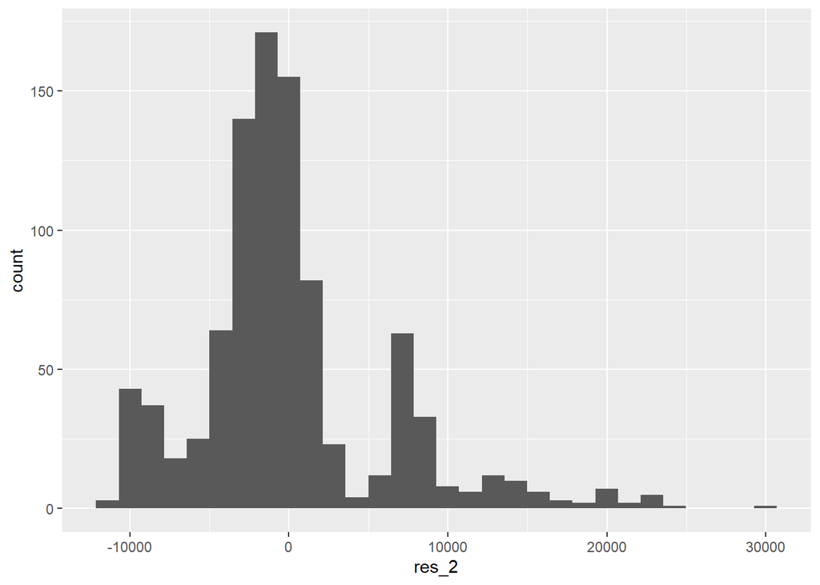

```r
ggplot(data.frame(res_2), aes(res_2)) + geom_histogram()
```

The data does not seem to be normally distributed. From visual observations, the data seems to be right skewed. The mean looks approximately centered at zero, but this can also be verified using t.test

```r
# Checking for assumption of zero mean using t.test()
t.test(res_2)
```

```
##
##  One Sample t-test
##
## data:  res_2
## t = 1.7178e-15, df = 935, p-value = 1
## alternative hypothesis: true mean is not equal to 0
## 95 percent confidence interval:
##  -389.311  389.311
## sample estimates:
##    mean of x
## 3.407585e-13
```

```r
# Creating dataframe for predictions and residuals using augment()

fit2_df <- fit2 %>%
    augment() %>%
    mutate(row_num = 1:n())
head(fit2_df)
```

| .rownames | charges | age | bmi | children | smoker | .fitted | .resid | .hat | .sigma | .cooksd | .std.resid | row_num |
| --- | --- | --- | --- | --- | --- | --- | --- | --- | --- | --- | --- | --- |
| 539 | 8233.097 | 46 | 28.050 | 1 | no | 9397.047 | -1163.949 | 0.001845317 | 6085.269 | 1.356636e-05 | -0.19154914 | 1 |
| 199 | 9644.253 | 51 | 18.050 | 0 | no | 7171.430 | 2472.823 | 0.008030299 | 6084.844 | 2.697994e-04 | 0.40821485 | 2 |
| 772 | 11150.780 | 53 | 26.700 | 2 | no | 11253.886 | -103.106 | 0.003511252 | 6085.388 | 2.032383e-07 | -0.01698216 | 3 |
| 216 | 7371.772 | 41 | 37.100 | 2 | no | 11321.836 | -3950.064 | 0.003048607 | 6084.006 | 2.587509e-04 | -0.65044735 | 4 |
| 1082 | 4454.403 | 32 | 27.835 | 1 | no | 5566.084 | -1111.681 | 0.001838144 | 6085.279 | 1.232702e-05 | -0.18294679 | 5 |
| 1077 | 8551.347 | 47 | 32.000 | 1 | no | 10916.636 | -2365.289 | 0.001688408 | 6084.893 | 5.124288e-05 | -0.38922089 | 6 |

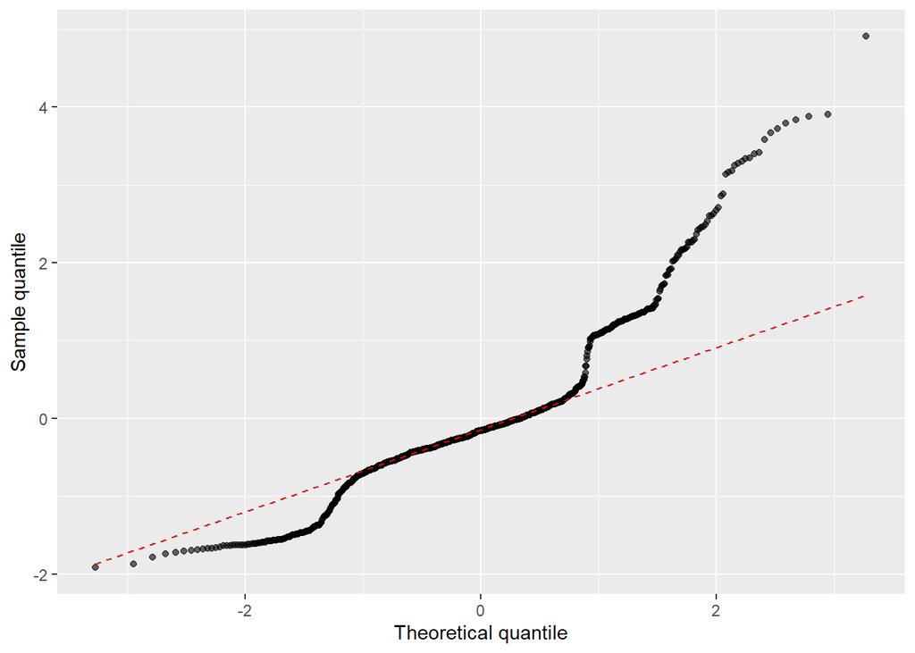

```r
# Q-Q plot
ggplot(fit2_df, aes(sample = .std.resid)) +
    geom_qq(alpha = 0.6, size = 1.5) +
    geom_qq_line(linetype = "dashed", color = "red2") +
    xlab("Theoretical quantile") +
    ylab("Sample quantile") +
    theme_grey()
```

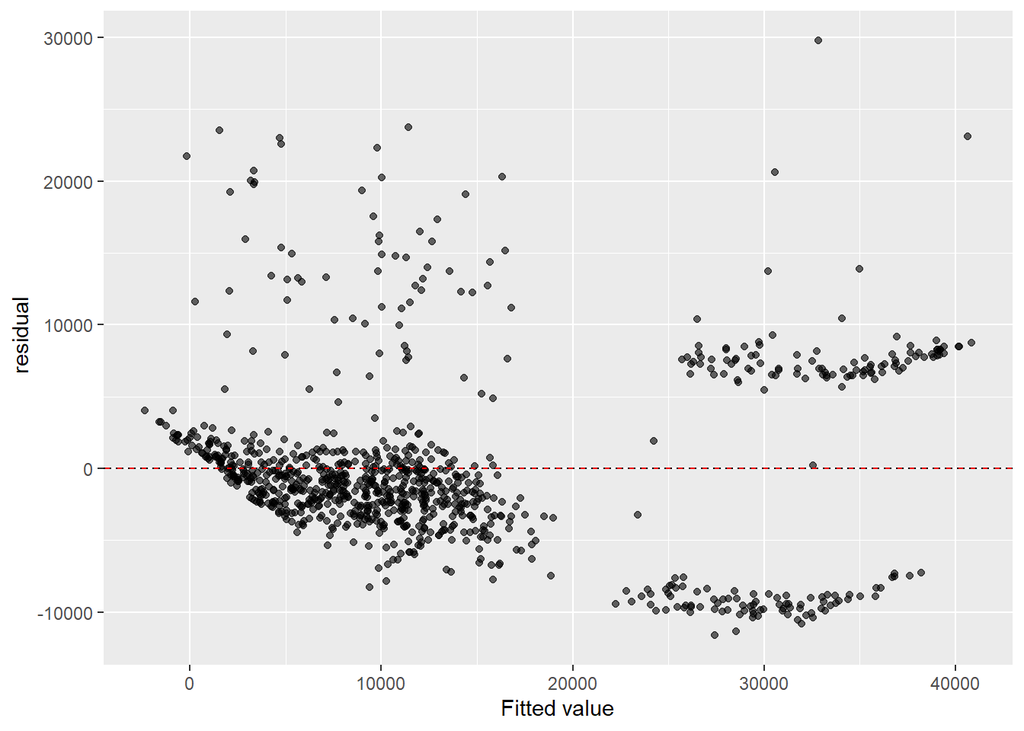

```r
# Fitted vs Residual
ggplot(fit2, aes(x = .fitted, y =.resid)) +
    geom_point(alpha = 0.6, size = 1.5) +
    geom_hline(yintercept = 0, linetype = "dashed", color = "red2") +
    geom_hline(yintercept = c(-2, 2), linetype = "dotted") +
    xlab("Fitted value") +
    ylab(" residual") +
    theme_grey()
```

From the above plots, we can infer that assumption of normality and constant variance has been violated.

```r
# Checking for multi-collinearity
car::vif(fit2)
```

```
##      age      bmi children   smoker
## 1.021275 1.016533 1.006398 1.001868
```

Since the VIF (Variance Inflation Factor) is < 10 for all parameters, the assumption of multi-collinearity has been met.

#### Applying box cox transformation

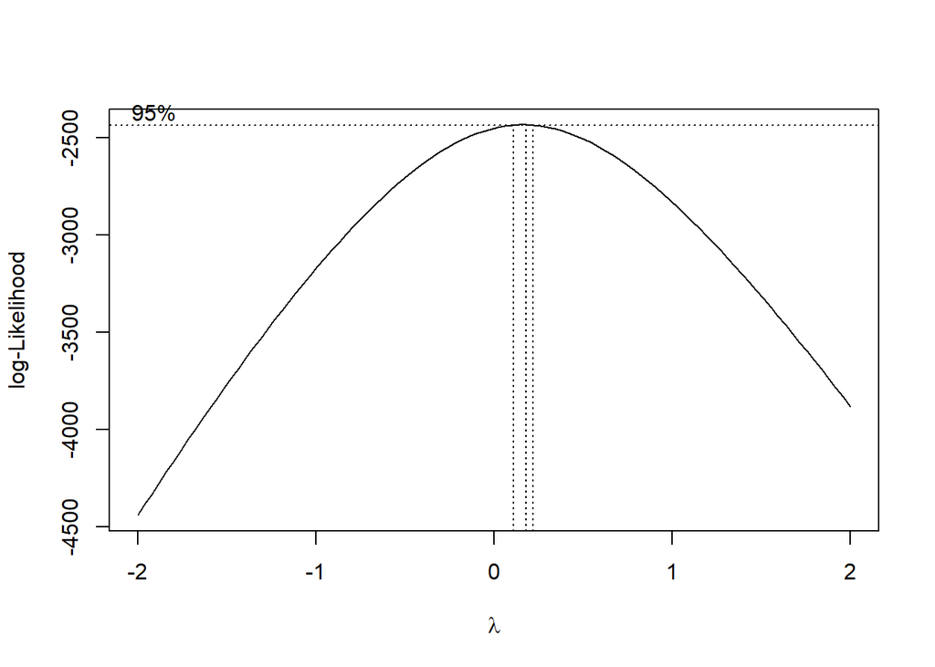

```r
# Find optimal lambda value via ML estimation
bc <- MASS::boxcox(charges ~ age + bmi + children + smoker, data=insurance_train)
```

```r
lambda <- bc$x[which.max(bc$y)]
print(lambda)
```

```
## [1] 0.1818182
```

```r
# boxcox transformed model
insurance_train$charges2 <- (insurance_train$charges ^ lambda - 1) / lambda
fit2_bc <- lm(charges2 ~ age + bmi + children + smoker, data=insurance_train)
summary(fit2_bc)
```

```
##
## Call:
## lm(formula = charges2 ~ age + bmi + children + smoker, data = insurance_train)
##
## Residuals:
##     Min      1Q  Median      3Q     Max
## -4.9638 -1.0948 -0.3677  0.2390 10.9508
##
## Coefficients:
##              Estimate Std. Error t value Pr(>|t|)
## (Intercept) 12.520200   0.424524  29.492  < 2e-16 ***
## age          0.172480   0.005456  31.615  < 2e-16 ***
## bmi          0.069442   0.012375   5.611 2.65e-08 ***
## children     0.458342   0.064155   7.144 1.82e-12 ***
## smokeryes    8.517053   0.186856  45.581  < 2e-16 ***
## ---
## Signif. codes:  0 '***' 0.001 '**' 0.01 '*' 0.05 '.' 0.1 ' ' 1
##
## Residual standard error: 2.315 on 931 degrees of freedom
## Multiple R-squared:  0.7719, Adjusted R-squared:  0.7709
## F-statistic: 787.6 on 4 and 931 DF,  p-value: < 2.2e-16
```

```r
# Store residual values
res_2b <- fit2_bc$residuals
str(res_2b)
```

```
##  Named num [1:936] -0.0281 1.089 0.0065 -0.816 -0.5924 ...
##  - attr(*, "names")= chr [1:936] "539" "199" "772" "216" ...
```

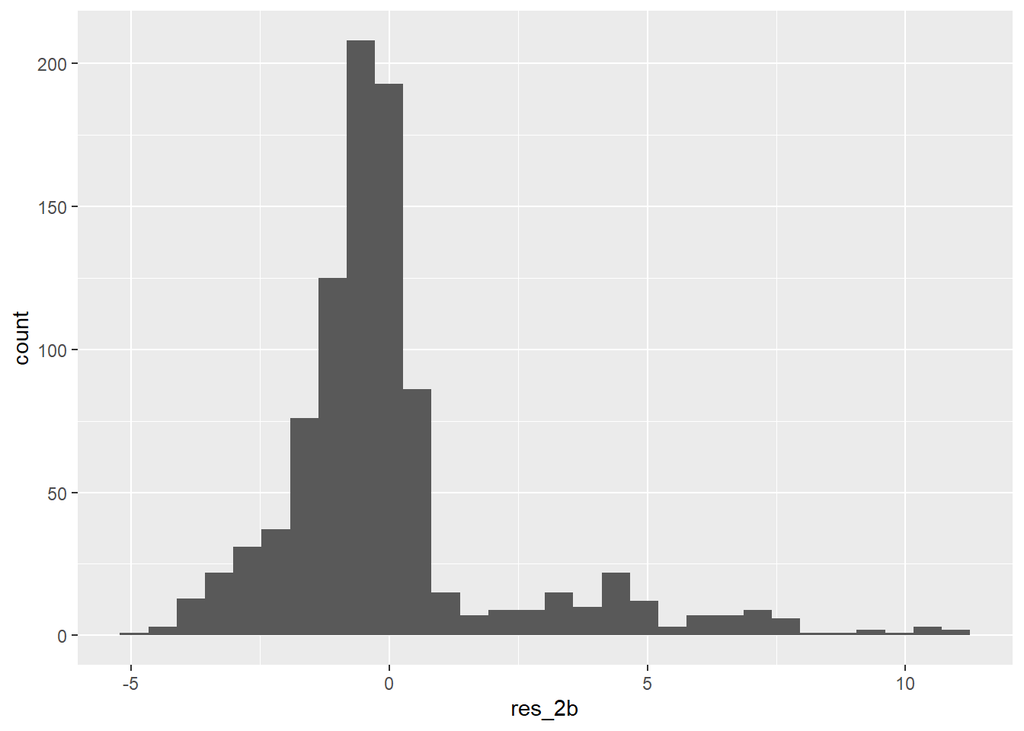

```r
par(mfrow = c(2,4))
ggplot(data.frame(res_2b), aes(res_2b)) + geom_histogram()
```

```r
# Creating dataframe for predictions and residuals using augment()

fit2b_df <- fit2_bc %>%
    augment() %>%
    mutate(row_num = 1:n())
head(fit2b_df)
```

| .rownames | charges2 | age | bmi | children | smoker | .fitted | .resid | .hat | .sigma | .cooksd | .std.resid | row_num |
| --- | --- | --- | --- | --- | --- | --- | --- | --- | --- | --- | --- | --- |
| 539 | 22.83239 | 46 | 28.050 | 1 | no | 22.86048 | -0.028087579 | 0.001845317 | 2.316323 | 5.452584e-08 | -0.012143661 | 1 |
| 199 | 23.65917 | 51 | 18.050 | 0 | no | 22.57012 | 1.089046821 | 0.008030299 | 2.316045 | 3.611823e-04 | 0.472314846 | 2 |
| 772 | 24.43894 | 53 | 26.700 | 2 | no | 24.43244 | 0.006496706 | 0.003511252 | 2.316323 | 5.569320e-09 | 0.002811197 | 3 |
| 216 | 22.26883 | 41 | 37.100 | 2 | no | 23.08487 | -0.816041605 | 0.003048607 | 2.316168 | 7.622135e-05 | -0.353028329 | 4 |
| 1082 | 19.83839 | 32 | 27.835 | 1 | no | 20.43083 | -0.592440934 | 0.001838144 | 2.316241 | 2.416385e-05 | -0.256140835 | 5 |
| 1077 | 23.02844 | 47 | 32.000 | 1 | no | 23.30726 | -0.278815698 | 0.001688408 | 2.316305 | 4.914486e-06 | -0.120536454 | 6 |

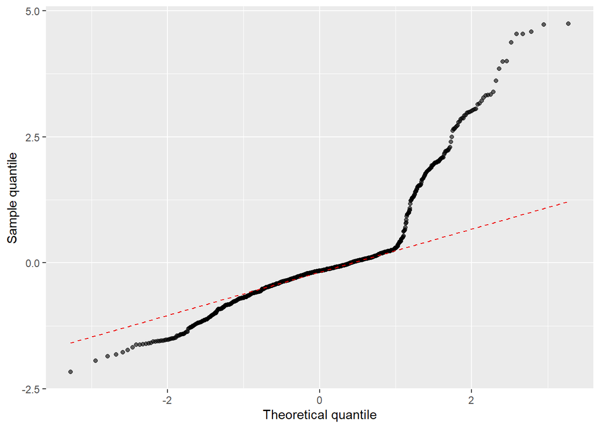

```r
# Q-Q plot
ggplot(fit2b_df, aes(sample = .std.resid)) +
    geom_qq(alpha = 0.6, size = 1.5) +
    geom_qq_line(linetype = "dashed", color = "red2") +
    xlab("Theoretical quantile") +
    ylab("Sample quantile") +
    theme_grey()
```

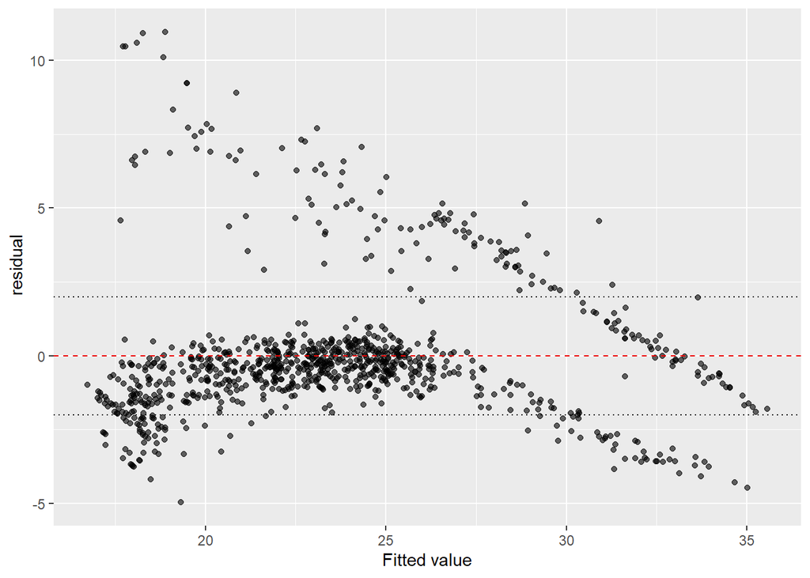

```r
# Fitted vs Residual
ggplot(fit2_bc, aes(x = .fitted, y =.resid)) +
    geom_point(alpha = 0.6, size = 1.5) +
    geom_hline(yintercept = 0, linetype = "dashed", color = "red2") +
    geom_hline(yintercept = c(-2, 2), linetype = "dotted") +
    xlab("Fitted value") +
    ylab(" residual") +
    theme_grey()
```

The r-squared value has improved slightly on applying box-cox transformation with a lambda value of 0.1818, but the assumption of normality is still being violated.

#### Transforming test data

```r
insurance_test$charges2 <- (insurance_test$charges ^ lambda - 1) / lambda
```

```r
# Calculating predicted values for test data
fit2bc_preds <- predict(fit2_bc, insurance_test)
str(fit2bc_preds)
```

```
##  Named num [1:402] 21 19.8 19.7 22.2 24.7 ...
##  - attr(*, "names")= chr [1:402] "3" "4" "6" "8" ...
```

#### Calculating model performance metrics

```r
calc_performance <- function(actual, pred) {

  rmse <- sqrt(mean((actual - pred)**2))
  mae <- mean(abs(actual - pred))
  mape <- mean(abs((actual-pred)/actual))

  retvals <- list(rmse = rmse, mae = mae, mape = mape)
  return(retvals)
}
```

```r
# Model performance metrics for the model without transformation

metrics_1 <- calc_performance(insurance_test$charges,fit2_preds)
metrics_1
```

```
## $rmse
## [1] 6052.649
##
## $mae
## [1] 4118.917
##
## $mape
## [1] 0.4080027
```

```r
# Model performance metrics for transformed model

metrics_2 <- calc_performance(insurance_test$charges2,fit2bc_preds)
metrics_2
```

```
## $rmse
## [1] 2.304419
##
## $mae
## [1] 1.453319
##
## $mape
## [1] 0.06058086
```

RMSE values for both the models cannot be compared since the one of them is a transformed one. On comparing MAPE (Mean absolute percentage error), we can conclude that the transformed model is significantly better.